# Homework 11

Joyce Lin

2025-02-20

## Instructions

Answer the following questions and complete the exercises in RMarkdown. Please embed all of your code and push your final work to your repository. Your final lab report should be organized, clean, and run free from errors. Remember, you must remove the `#` for the included code chunks to run. Be sure to add your name to the author header above.

Make sure to use the formatting conventions of RMarkdown to make your report neat and clean!

## Background

In the `data` folder, you will find data about shark incidents in California between 1950-2022. The [data](https://catalog.data.gov/dataset/shark-incident-database-california-56167) are from: State of California- Shark Incident Database.

## Load the libraries

```r
library("tidyverse")
library("janitor")
library("naniar")
```

## Load the data

Run the following code chunk to import the data.

```r
sharks <- read_csv("data/SharkIncidents_1950_2022_220302.csv") %>% clean_names()
```

## Questions

```r
sharks
```

```
## # A tibble: 211 × 16
##    incident_num month   day  year time    county     location mode  injury depth
##    <chr>        <dbl> <dbl> <dbl> <chr>   <chr>      <chr>    <chr> <chr>  <chr>
##  1 1               10     8  1950 12:00   San Diego  Imperia… Swim… major  surf…
##  2 2                5    27  1952 14:00   San Diego  Imperia… Swim… minor  surf…
##  3 3               12     7  1952 14:00   Monterey   Lovers … Swim… fatal  surf…
##  4 4                2     6  1955 12:00   Monterey   Pacific… Free… minor  surf…
##  5 5                8    14  1956 16:30   San Luis … Pismo B… Swim… major  surf…
##  6 6                4    28  1957 13:30   San Luis … Morro B… Swim… fatal  surf…
##  7 7               10    12  1958 Unknown San Diego  Coronad… Swim… major  surf…
##  8 8                5     7  1959 17:30   San Franc… Baker B… Swim… fatal  surf…
##  9 9                6    14  1959 17:00   San Diego  La Jolla Free… fatal  surf…
## 10 10               7    28  1959 19:30   San Diego  La Jolla Free… minor  surf…
## # ℹ 201 more rows
## # ℹ 6 more variables: species <chr>, comment <chr>, longitude <chr>,
## #   latitude <dbl>, confirmed_source <chr>, wfl_case_number <chr>
```

```r
miss_var_summary(sharks)
```

```
## # A tibble: 16 × 3
##    variable         n_miss pct_miss
##    <chr>             <int>    <num>
##  1 wfl_case_number     202   95.7
##  2 time                  7    3.32
##  3 latitude              6    2.84
##  4 longitude             5    2.37
##  5 confirmed_source      1    0.474
##  6 incident_num          0    0
##  7 month                 0    0
##  8 day                   0    0
##  9 year                  0    0
## 10 county                0    0
## 11 location              0    0
## 12 mode                  0    0
## 13 injury                0    0
## 14 depth                 0    0
## 15 species               0    0
## 16 comment               0    0
```

2. Notice that there are some incidents identified as “NOT COUNTED”. These should be removed from the data because they were either not sharks, unverified, or were provoked. It’s OK to replace the `sharks` object.

```r
sharks <- sharks %>%
  filter(incident_num!="NOT COUNTED")
```

3. Are there any “hotspots” for shark incidents in California? Make a table and plot that shows the total number of incidents per county. Which county has the highest number of incidents? *San Diego has the highest number of incidents*

```r
sharks %>%
  count(county) %>%
  arrange(-n)
```

```
## # A tibble: 21 × 2
##    county              n
##    <chr>           <int>
##  1 San Diego          23
##  2 Santa Barbara      19
##  3 Humboldt           18
##  4 San Mateo          18
##  5 Marin              16
##  6 Monterey           15
##  7 Santa Cruz         15
##  8 Sonoma             15
##  9 San Luis Obispo    14
## 10 Los Angeles         9
## # ℹ 11 more rows
```

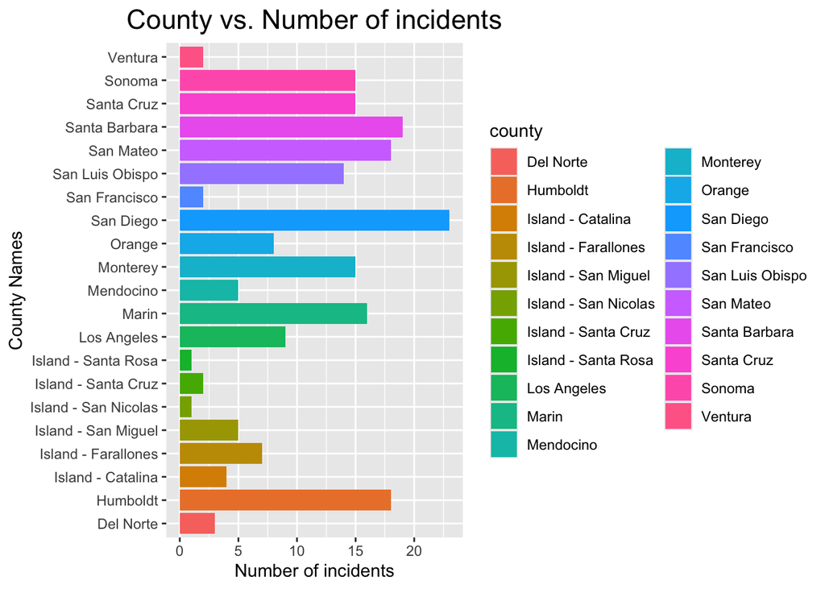

```r
sharks %>%
  count(county) %>%
  ggplot(aes(x=county, y=n, fill=county))+
  geom_col()+
  coord_flip()+
  labs(title="County vs. Number of incidents",
       x="County Names",
       y="Number of incidents")+
  theme(plot.title = element_text(size=rel(1.5), hjust=0.5))
```

4. Are there months of the year when incidents are more likely to occur? Make a table and a plot that shows the total number of incidents by month. Which month has the highest number of incidents?  
   *October has the highest number of incidents*

```r
sharks %>%
  count(month) %>%
  arrange(-n)
```

```
## # A tibble: 12 × 2
##    month     n
##    <dbl> <int>
##  1    10    36
##  2     8    31
##  3     9    31
##  4     7    23
##  5     5    16
##  6    11    16
##  7     6    14
##  8    12    13
##  9     1     7
## 10     4     6
## 11     3     5
## 12     2     4
```

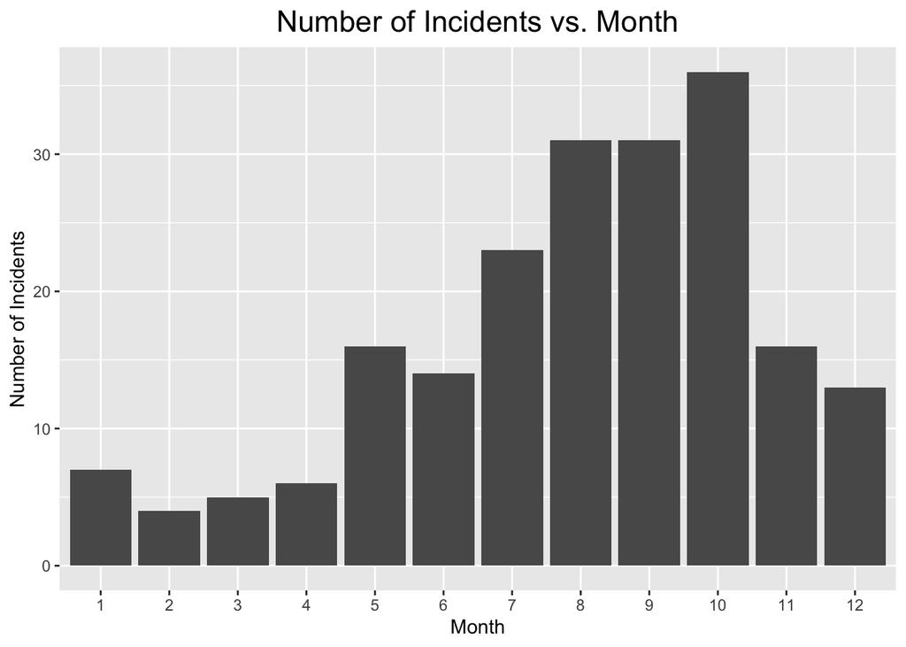

```r
sharks %>%
  count(month) %>%
  ggplot(aes(x=as_factor(month), y=n))+
  geom_col()+
  labs(title = "Number of Incidents vs. Month",
       x="Month",
       y="Number of Incidents")+
  theme(plot.title = element_text(size=rel(1.5), hjust=0.5))
```

5. How do the number and types of injuries compare by county? Make a table that shows the number of injury types by county. Which county has the highest number incidents?

**This table shows the total number of incidents by county, and San Diego has the highest total number of injuries among all the counties**

```r
sharks %>%
  group_by(county, injury) %>%
  summarize(num_inju=n(), .groups="keep") %>%
  pivot_wider(names_from = injury, values_from = num_inju) %>%
  mutate(total_incidents=rowSums(across(where(is.numeric)), na.rm=T)) %>%
  arrange(-total_incidents)
```

```
## # A tibble: 21 × 6
## # Groups:   county [21]
##    county          minor  none major fatal total_incidents
##    <chr>           <int> <int> <int> <int>           <dbl>
##  1 San Diego           8     9     4     2              23
##  2 Santa Barbara       6     9     2     2              19
##  3 Humboldt            2     9     7    NA              18
##  4 San Mateo           4    12     1     1              18
##  5 Marin               4     3     9    NA              16
##  6 Monterey            2     3     8     2              15
##  7 Santa Cruz          3     8     3     1              15
##  8 Sonoma              1     6     8    NA              15
##  9 San Luis Obispo     1     7     3     3              14
## 10 Los Angeles         6     2    NA     1               9
## # ℹ 11 more rows
```

6. Use the table from #5 to make a plot that shows the total number of incidents by county.

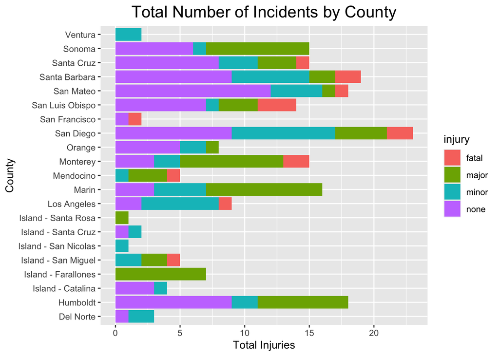

```r
sharks %>%
  ggplot(aes(x=county, fill = injury))+
  geom_bar()+
  coord_flip()+
  labs(title = "Total Number of Incidents by County",
       x="County",
       y="Total Injuries")+
  theme(plot.title = element_text(size=rel(1.5), hjust=0.5))
```

7. In the data, `mode` refers to a type of activity. Which activity is associated with the highest number of incidents?

*Surfing/Boarding is associated with the highest number of incidents*

```r
sharks %>%
  count(mode) %>%
  arrange(-n)
```

```
## # A tibble: 7 × 2
##   mode                    n
##   <chr>               <int>
## 1 Surfing / Boarding     80
## 2 Freediving             35
## 3 Kayaking / Canoeing    29
## 4 Swimming               22
## 5 Scuba Diving           19
## 6 Hookah Diving          10
## 7 Paddleboarding          7
```

8. Make a plot that compares the number of incidents by activity.

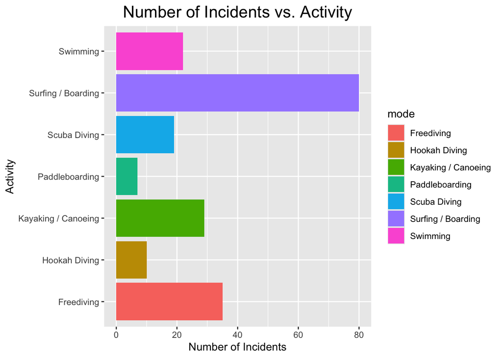

```r
sharks %>%
  ggplot(aes(x=mode, fill=mode))+
  geom_bar()+
  coord_flip()+
  labs(title = "Number of Incidents vs. Activity",
       x="Activity",
       y="Number of Incidents")+
  theme(plot.title = element_text(size=rel(1.5), hjust=0.5))
```

9. Which shark species is involved in the highest number of incidents?

*White shark is involed in the highest number of incidents*

```r
sharks %>%
  count(species) %>%
  arrange(-n)
```

```
## # A tibble: 8 × 2
##   species        n
##   <chr>      <int>
## 1 White        179
## 2 Unknown       13
## 3 Hammerhead     3
## 4 Blue           2
## 5 Leopard        2
## 6 Salmon         1
## 7 Sevengill      1
## 8 Thresher       1
```

10. Are all incidents involving Great White’s fatal? Make a plot that shows the number and types of incidents for Great White’s only.

*No, only less than 20 incidents involving Great White sharks are fatal*

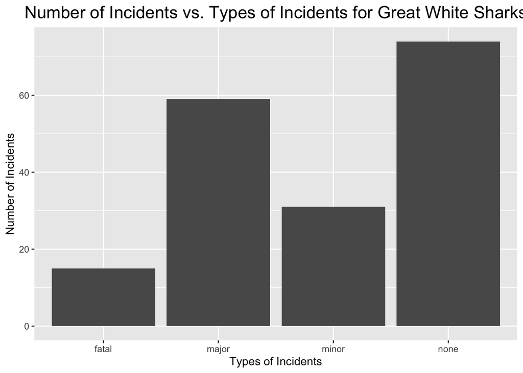

```r
sharks %>%
  filter(species=="White") %>%
  ggplot(aes(x=injury))+
  geom_bar()+
  labs(title = "Number of Incidents vs. Types of Incidents for Great White Sharks",
       x="Types of Incidents",
       y="Number of Incidents")+
  theme(plot.title = element_text(size=rel(1.5), hjust=0.5))
```